# Clase 1: Introducción a R

Econometría 1 — ECON 3311 / ECON 3321

Brayan David Flórez | Profesor complementario

2026-19

> **Universidad de los Andes** | Facultad de Economía  
> Clase complementaria — Viernes de 7 a 10 AM  
> Profesor magistral: Edicson Luna · Complementario: Brayan David Flórez

# 1 Introducción al curso

## 1.1 ¿De qué trata Econometría 1?

El método del economista tiene dos pilares fundamentales:

1. **Modelos teóricos formales** para describir relaciones entre variables económicas.
2. **Analítica de datos** para cuantificar dichas relaciones con base en información del mundo real.

Estas cuantificaciones se dividen en dos grandes grupos:

- **Estimación de relaciones causales:** ¿Cuánto aumenta el salario con un año adicional de educación? ¿Qué efecto tiene una política pública sobre las decisiones de las empresas?
- **Predicciones:** ¿Cuál será el crecimiento del PIB el próximo año? ¿Qué tan probable es que un deudor no pague?

El conjunto de herramientas estadísticas que usan los economistas para hacer estas cuantificaciones es la **econometría**. Este curso se enfoca en el **modelo de regresión lineal**.

## 1.2 Información del equipo pedagógico

| Rol | Nombre | Correo |
| --- | --- | --- |
| Profesor magistral | Edicson Luna | edicson@sas.upenn.edu |
| Profesor complementario. | Brayan David Flórez | b.florezl@uniandes.edu.co |

- **Clase magistral:** Lunes, martes y jueves 8–10 AM; miércoles 7–10 AM
- **Clase complementaria:** Viernes 7–10 AM *(esta clase)*

# 2 Objetivos del curso

Al finalizar exitosamente **Econometría 1**, el estudiante:

| Código | Resultado de aprendizaje |
| --- | --- |
| **R.A.1** | Sabe cuantificar relaciones entre variables económicas. |
| **R.A.2** | Conoce los aspectos básicos del análisis econométrico. |
| **R.A.3** | Conoce las principales limitaciones del análisis econométrico. |
| **R.A.4** | Aplica el instrumental econométrico para diferenciar correlación de causalidad. |
| **R.A.5** | Propone e investiga preguntas empíricas con relevancia económica. |

**El objetivo de las clases complementarias** es que domines las herramientas computacionales (R) necesarias para alcanzar estos resultados de aprendizaje.

# 3 Organización del curso

## 3.1 Cronograma general

| Semana | Fechas | Temas | Evaluación |
| --- | --- | --- | --- |
| **1** | 16 – 20 jun | Repaso de estadística | — |
| **2** | 23 – 27 jun | Repaso de estadística · Estimador OLS | **Quiz 1** · mié 24 jun |
| **3** | 30 jun – 4 jul | Insesgamiento · Inferencia estadística | **Quiz 2** · mié 1 jul |
| **4** | 7 – 11 jul | Tipos de variables · Teoría asintótica | — |
| **5** | 14 – 18 jul | Principios de inferencia causal | **Quiz 3** · mié 15 jul |
| **6** | 21 – 24 jul | Variable dicotómica dependiente · Presentaciones | **Examen Final** · jue 23 jul |

> **Presentaciones:** Última semana de clases

## 3.2 Sistema de evaluación

**Estudiantes con 3 créditos:**

| Evaluación | Porcentaje |
| --- | --- |
| Quiz 1 | 10% |
| Quiz 2 | 10% |
| Quiz 3 | 10% |
| Examen Final | 20% |
| Trabajo 1 | 20% |
| Trabajo 2 | 20% |
| Presentaciones | 10% |

**Estudiantes con 4 créditos (con taller):**

| Evaluación | Porcentaje |
| --- | --- |
| Quiz 1 | 10% |
| Quiz 2 | 10% |
| Quiz 3 | 10% |
| Examen Final | 20% |
| Trabajo 1 | 15% |
| Trabajo 2 | 15% |
| Presentaciones | 10% |
| Manejo de datos | 10% |

## 3.3 Referencias del curso

- **(R)** Ross, S. (2017). *Introductory Statistics*, 4th ed.
- **(WO)** Wooldridge, J. M. (2010). *Introductory Econometrics: A Modern Approach*, 6th ed.
- **(AP)** Angrist & Pischke (2014). *Mastering Metrics: The Path from Cause to Effect.*
- **(MH)** Angrist & Pischke (2008). *Mostly Harmless Econometrics.*

# 4 Hoy veremos

1. **Motivación** — ¿por qué aprender R?
2. **¿Por qué usar R?** — ventajas frente a otras herramientas
3. **Configuración inicial** — instalar R y RStudio
4. **Interfaz de RStudio** — paneles y flujo de trabajo
5. **Primeros pasos en R** — objetos, operaciones, vectores, data frames y funciones básicas
6. **Importar datos** — tres formatos que circulan en economía
7. **Tablas y estadísticas descriptivas** — con datos reales
8. **Gráficos** — con `ggplot2`

# 5 Motivación: ¿por qué aprender R?

## 5.1 R en el mercado laboral colombiano

Una forma de medir la popularidad de un lenguaje es observar cuántas ofertas de trabajo lo requieren. Los siguientes gráficos muestran la demanda de lenguajes estadísticos en Colombia y en el mercado global.

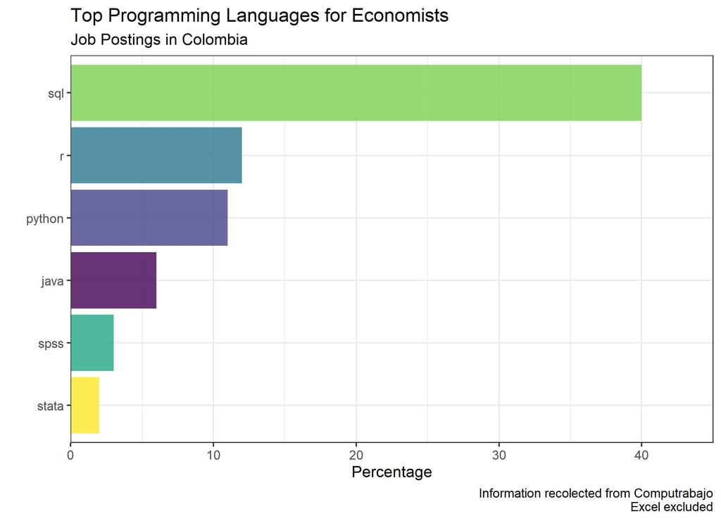

Top lenguajes de programación para economistas en Colombia. Fuente: Computrabajo (Excel excluido).

**Lectura del gráfico:** En las ofertas de trabajo para economistas en Colombia, **R es el segundo lenguaje más demandado** (≈12%), después de SQL y por encima de Python. Stata, que fue el estándar histórico en economía, aparece con apenas ~2%.

## 5.2 R en el mercado laboral global

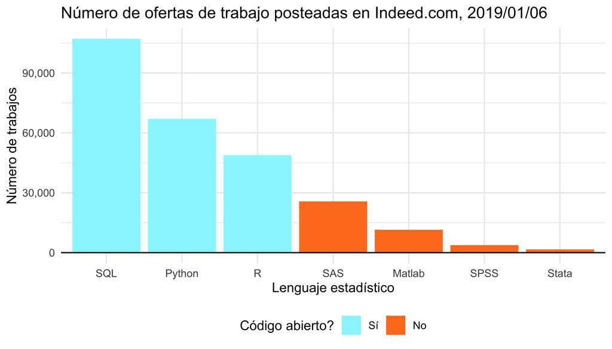

Número de ofertas de trabajo en Indeed.com por lenguaje estadístico (enero 2019). Los lenguajes de código abierto (azul) dominan el mercado.

# 6 Configuración inicial

## 6.1 Instalar R

1. Ve a https://cran.r-project.org/
2. Selecciona tu sistema operativo (Windows / macOS / Linux).
3. Descarga la versión más reciente (R 4.x.x).
4. Sigue el instalador con las opciones por defecto.

## 6.2 Instalar RStudio

1. Ve a https://posit.co/download/rstudio-desktop/
2. Descarga la versión gratuita de **RStudio Desktop**.
3. Instala **después** de haber instalado R.

> **Importante:** R es el motor; RStudio es la cabina de pilotaje. Necesitas ambos.

## 6.3 Instalar paquetes

Los **paquetes** (o librerías) extienden las capacidades de R. En este curso usaremos principalmente:

```r
# Ejecuta esto UNA sola vez en tu computador
# install.packages("pacman")
```

Una vez instalados, se cargan con `library()` al inicio de cada sesión:

```r
library(pacman)
p_load(tidyverse,  # manipulación y visualización de datos
       haven,      # leer archivos .dta (Stata), .sav (SPSS)
       readxl,     # leer archivos Excel
       knitr,      # tablas y compilación de documentos
       stargazer,  # tablas de regresión
       lmtest,     # pruebas sobre modelos lineales
       sandwich)   # errores estándar robustos
```

# 7 Interfaz de RStudio

## 7.1 Los cuatro paneles principales

[figure not shown]

| Panel | Función principal |
| --- | --- |
| **Editor** | Escribir y guardar scripts o documentos R Markdown |
| **Consola** | Ejecutar comandos directamente; ver resultados |
| **Environment** | Ver los objetos creados en la sesión actual |
| **Plots / Help** | Ver gráficas, buscar documentación de funciones |

## 7.2 Configurar el directorio de trabajo

```r
# Ver dónde está trabajando R ahora mismo
getwd()

# Cambiar el directorio de trabajo (ajusta la ruta a tu computador)
#setwd("C:/Users/TuUsuario/Documentos/econometria1")
```

# 8 Primeros pasos en R

## 8.1 R como calculadora

R puede usarse como una calculadora sofisticada directamente en la consola:

```r
# Operaciones aritméticas básicas
2 + 3
```

```
#> [1] 5
```

```r
10 - 4
```

```
#> [1] 6
```

```r
6 * 7
```

```
#> [1] 42
```

```r
15 / 4
```

```
#> [1] 3.75
```

```r
2^10          # potenciación
```

```
#> [1] 1024
```

```r
sqrt(144)     # raíz cuadrada
```

```
#> [1] 12
```

```r
log(exp(1))   # logaritmo natural
```

```
#> [1] 1
```

Los `#` son **comentarios**: R los ignora al ejecutar el código. Úsenlos siempre para documentar su trabajo.

## 8.2 Asignación de objetos

En R, los resultados se guardan en **objetos** con el operador `<-` (o `=`):

```r
# Crear objetos
x <- 5
y <- 3
z <- x + y
z
```

```
#> [1] 8
```

```r
# También puedes usar =, aunque <- es la convención para evitar confusiones
nombre <- "Econometría 1"
nombre
```

```
#> [1] "Econometría 1"
```

El panel **Environment** muestra todos los objetos creados en la sesión.

## 8.3 Tipos de datos básicos

```r
# Numérico (numeric)
salario <- 3500000
class(salario)
```

```
#> [1] "numeric"
```

```r
# Texto / cadena (character)
ciudad <- "Bogotá"
class(ciudad)
```

```
#> [1] "character"
```

```r
# Lógico (logical)
es_estudiante <- TRUE
class(es_estudiante)
```

```
#> [1] "logical"
```

```r
# Entero (integer)
semestre <- 5L
class(semestre)
```

```
#> [1] "integer"
```

## 8.4 Vectores

Un **vector** es una secuencia de elementos del mismo tipo. Es la estructura más básica de R:

```r
# Crear vectores con c() (concatenar)
edades    <- c(20, 21, 19, 22, 20, 23)
nombres   <- c("Ana", "Luis", "María", "Carlos", "Juan", "Sofía")
en_beca   <- c(TRUE, FALSE, TRUE, FALSE, TRUE, FALSE)

# Longitud del vector
length(edades)
```

```
#> [1] 6
```

```r
# Acceder a elementos por posición (índice empieza en 1)
edades[1]       # primer elemento
```

```
#> [1] 20
```

```r
edades[3]       # tercer elemento
```

```
#> [1] 19
```

```r
edades[2:4]     # elementos del 2 al 4
```

```
#> [1] 21 19 22
```

```r
edades[c(1,5)]  # elementos 1 y 5
```

```
#> [1] 20 20
```

### 8.4.1 Operaciones sobre vectores

```r
# Las operaciones se aplican elemento a elemento
salarios <- c(2800000, 3500000, 4200000, 3100000, 2950000, 5000000)

# Transformaciones
salarios_millones <- salarios / 1e6
salarios_millones
```

```
#> [1] 2.80 3.50 4.20 3.10 2.95 5.00
```

```r
# Estadísticas básicas
mean(salarios)     # media
```

```
#> [1] 3591667
```

```r
median(salarios)   # mediana
```

```
#> [1] 3300000
```

```r
sd(salarios)       # desviación estándar
```

```
#> [1] 853473.3
```

```r
var(salarios)      # varianza
```

```
#> [1] 728416666667
```

```r
min(salarios)      # mínimo
```

```
#> [1] 2800000
```

```r
max(salarios)      # máximo
```

```
#> [1] 5e+06
```

```r
sum(salarios)      # suma
```

```
#> [1] 21550000
```

### 8.4.2 Filtrar vectores con condiciones lógicas

```r
# ¿Cuáles edades son mayores a 20?
edades > 20
```

```
#> [1] FALSE  TRUE FALSE  TRUE FALSE  TRUE
```

```r
# Extraer solo los elementos que cumplen la condición
edades[edades > 20]
```

```
#> [1] 21 22 23
```

```r
# Operadores lógicos:
# >  mayor que    |  <  menor que
# >= mayor o igual|  <= menor o igual
# == igual a      |  != diferente de
# &  Y (and)      |  |  O (or)
# !  NO (negación)

edades[edades >= 20 & edades <= 22]
```

```
#> [1] 20 21 22 20
```

## 8.5 Matrices

```r
# Crear una matriz
M <- matrix(1:9, nrow = 3, ncol = 3)
M
```

```
#>      [,1] [,2] [,3]
#> [1,]    1    4    7
#> [2,]    2    5    8
#> [3,]    3    6    9
```

```r
# Dimensiones
dim(M)
```

```
#> [1] 3 3
```

```r
nrow(M)
```

```
#> [1] 3
```

```r
ncol(M)
```

```
#> [1] 3
```

```r
# Acceso a elementos: M[fila, columna]
M[2, 3]     # fila 2, columna 3
```

```
#> [1] 8
```

```r
M[1, ]      # toda la fila 1
```

```
#> [1] 1 4 7
```

```r
M[, 2]      # toda la columna 2
```

```
#> [1] 4 5 6
```

```r
# Álgebra matricial (relevante para OLS)
A <- matrix(c(1, 2, 3, 4), nrow = 2)
B <- matrix(c(5, 6, 7, 8), nrow = 2)

A %*% B      # multiplicación matricial
```

```
#>      [,1] [,2]
#> [1,]   23   31
#> [2,]   34   46
```

```r
t(A)         # transpuesta
```

```
#>      [,1] [,2]
#> [1,]    1    2
#> [2,]    3    4
```

```r
solve(A)     # inversa (si existe)
```

```
#>      [,1] [,2]
#> [1,]   -2  1.5
#> [2,]    1 -0.5
```

## 8.6 Data Frames

El **data frame** es la estructura más importante en econometría: una tabla donde cada columna es una variable y cada fila es una observación.

```r
# Crear un data frame
estudiantes <- data.frame(
  nombre    = c("Ana", "Luis", "María", "Carlos", "Juan", "Sofía"),
  semestre  = c(5, 5, 4, 5, 6, 4),
  promedio  = c(3.9, 3.5, 4.1, 3.2, 3.7, 4.3),
  beca      = c(TRUE, FALSE, TRUE, FALSE, TRUE, FALSE)
)

# Ver el data frame
estudiantes
```

| nombre | semestre | promedio | beca |
| --- | --- | --- | --- |
| Ana | 5 | 3.9 | TRUE |
| Luis | 5 | 3.5 | FALSE |
| María | 4 | 4.1 | TRUE |
| Carlos | 5 | 3.2 | FALSE |
| Juan | 6 | 3.7 | TRUE |
| Sofía | 4 | 4.3 | FALSE |

```r
# Dimensiones
nrow(estudiantes)   # número de observaciones
```

```
#> [1] 6
```

```r
ncol(estudiantes)   # número de variables
```

```
#> [1] 4
```

```r
# Nombres de las variables (columnas)
names(estudiantes)
```

```
#> [1] "nombre"   "semestre" "promedio" "beca"
```

```r
# Primeras y últimas filas
head(estudiantes, 3)
```

|  | nombre | semestre | promedio | beca |
| --- | --- | --- | --- | --- |
| 1 | Ana | 5 | 3.9 | TRUE |
| 2 | Luis | 5 | 3.5 | FALSE |
| 3 | María | 4 | 4.1 | TRUE |

```r
tail(estudiantes, 2)
```

|  | nombre | semestre | promedio | beca |
| --- | --- | --- | --- | --- |
| 5 | Juan | 6 | 3.7 | TRUE |
| 6 | Sofía | 4 | 4.3 | FALSE |

```r
# Resumen estadístico
summary(estudiantes)
```

```
#>     nombre             semestre        promedio        beca
#>  Length:6           Min.   :4.000   Min.   :3.200   Mode :logical
#>  Class :character   1st Qu.:4.250   1st Qu.:3.550   FALSE:3
#>  Mode  :character   Median :5.000   Median :3.800   TRUE :3
#>                     Mean   :4.833   Mean   :3.783
#>                     3rd Qu.:5.000   3rd Qu.:4.050
#>                     Max.   :6.000   Max.   :4.300
```

### 8.6.1 Acceder a variables de un data frame

```r
# Con el operador $
estudiantes$promedio
```

```
#> [1] 3.9 3.5 4.1 3.2 3.7 4.3
```

```r
# Con corchetes [fila, columna]
estudiantes[1, ]          # primera observación (fila)
```

|  | nombre | semestre | promedio | beca |
| --- | --- | --- | --- | --- |
| 1 | Ana | 5 | 3.9 | TRUE |

```r
estudiantes[, "promedio"] # columna por nombre
```

```
#> [1] 3.9 3.5 4.1 3.2 3.7 4.3
```

```r
estudiantes[2, 3]         # fila 2, columna 3
```

```
#> [1] 3.5
```

### 8.6.2 Filtrar filas

```r
# Estudiantes con promedio mayor a 3.8
estudiantes[estudiantes$promedio > 3.8, ]
```

|  | nombre | semestre | promedio | beca |
| --- | --- | --- | --- | --- |
| 1 | Ana | 5 | 3.9 | TRUE |
| 3 | María | 4 | 4.1 | TRUE |
| 6 | Sofía | 4 | 4.3 | FALSE |

```r
# Con la función subset()
subset(estudiantes, beca == TRUE)
```

|  | nombre | semestre | promedio | beca |
| --- | --- | --- | --- | --- |
| 1 | Ana | 5 | 3.9 | TRUE |
| 3 | María | 4 | 4.1 | TRUE |
| 5 | Juan | 6 | 3.7 | TRUE |

```r
# Con tidyverse (filter) — esta es la forma que usaremos en el curso
filter(estudiantes, semestre == 5 & promedio > 3.5)
```

| nombre | semestre | promedio | beca |
| --- | --- | --- | --- |
| Ana | 5 | 3.9 | TRUE |

### 8.6.3 Agregar variables

```r
# Crear nueva columna
estudiantes$promedio_ponderado <- estudiantes$promedio * 1.1

# Con mutate (tidyverse) — esta es la forma que usaremos en el curso
estudiantes <- mutate(estudiantes,
                      es_excelente = promedio >= 4.0)
estudiantes
```

| nombre | semestre | promedio | beca | promedio_ponderado | es_excelente |
| --- | --- | --- | --- | --- | --- |
| Ana | 5 | 3.9 | TRUE | 4.29 | FALSE |
| Luis | 5 | 3.5 | FALSE | 3.85 | FALSE |
| María | 4 | 4.1 | TRUE | 4.51 | TRUE |
| Carlos | 5 | 3.2 | FALSE | 3.52 | FALSE |
| Juan | 6 | 3.7 | TRUE | 4.07 | FALSE |
| Sofía | 4 | 4.3 | FALSE | 4.73 | TRUE |

## 8.7 Funciones

En R todo se hace con **funciones**. También puedes crear las tuyas:

```r
# Estructura:
# nombre_funcion <- function(arg1, arg2, ...) {
#   cuerpo
#   return(resultado)
# }

# Ejemplo: calcular el coeficiente de variación
coef_variacion <- function(x) {
  cv <- sd(x) / mean(x) * 100
  return(cv)
}

coef_variacion(estudiantes$promedio)
```

```
#> [1] 10.62761
```

```r
# Función con valor por defecto
describir <- function(x, decimales = 2) {
  cat("N         :", length(x), "\n")
  cat("Media     :", round(mean(x),   decimales), "\n")
  cat("Mediana   :", round(median(x), decimales), "\n")
  cat("Desv. Est.:", round(sd(x),     decimales), "\n")
  cat("Mín       :", round(min(x),    decimales), "\n")
  cat("Máx       :", round(max(x),    decimales), "\n")
}

describir(estudiantes$promedio)
```

```
#> N         : 6
#> Media     : 3.78
#> Mediana   : 3.8
#> Desv. Est.: 0.4
#> Mín       : 3.2
#> Máx       : 4.3
```

# 9 Importar datos

La base que usamos hoy es **Saber 11 — 2019**: resultados del examen de Estado para 54.638 estudiantes colombianos. Descarguen los tres archivos de Bloque Neón y guárdenlos en la carpeta `datos/` de su proyecto:

[output not shown]

## 9.1 Organización del proyecto

La práctica más ordenada es definir las rutas al inicio del script:

```r
# Carpeta relativa al proyecto de RStudio — ajusten si es necesario
ruta_datos <- "datos"
```

> **Tip:** si usan un **proyecto de RStudio** (`.Rproj`), el directorio de trabajo queda fijado en la carpeta del proyecto automáticamente. No necesitan `setwd()`.

## 9.2 `.dta` — formato Stata

El formato más común en economía. Se carga con el paquete `haven`:

```r
sb11 <- read_dta(file.path(ruta_datos, "SB11_2019_Stata.dta"))
```

## 9.3 `.xlsx` — Excel

```r
sb11_xl <- read_excel(file.path(ruta_datos, "SB11_2019_Excel.xlsx"))
```

> Para archivos separados por comas: `read_csv()`. Para cualquier otro separador: `read_delim(..., delim = ";")`.

```r
dim(sb11)
```

```
#> [1] 54638    25
```

```r
dim(sb11_xl)
```

```
#> [1] 32783    25
```

# 10 Exploración inicial de una base nueva

Antes de cualquier análisis, siempre hay que conocer la base.

```r
nrow(sb11)   # observaciones
```

```
#> [1] 54638
```

```r
ncol(sb11)   # variables
```

```
#> [1] 25
```

```r
names(sb11)  # nombres de columnas
```

```
#>  [1] "estu_genero"                   "estu_fechanacimiento"
#>  [3] "periodo"                       "estu_depto_reside"
#>  [5] "estu_cod_reside_depto"         "estu_mcpio_reside"
#>  [7] "estu_cod_reside_mcpio"         "fami_estratovivienda"
#>  [9] "fami_educacionpadre"           "fami_educacionmadre"
#> [11] "fami_trabajolaborpadre"        "fami_trabajolabormadre"
#> [13] "fami_tieneinternet"            "fami_tienecomputador"
#> [15] "cole_cod_dane_establecimiento" "cole_nombre_establecimiento"
#> [17] "cole_naturaleza"               "cole_jornada"
#> [19] "punt_lectura_critica"          "punt_matematicas"
#> [21] "punt_c_naturales"              "punt_sociales_ciudadanas"
#> [23] "punt_ingles"                   "punt_global"
#> [25] "EDAD_ESTUDIANTES"
```

```r
head(sb11, 5)
```

| estu_genero | estu_fechanacimiento | periodo | estu_depto_reside | estu_cod_reside_depto | estu_mcpio_reside | estu_cod_reside_mcpio | fami_estratovivienda | fami_educacionpadre | fami_educacionmadre | fami_trabajolaborpadre | fami_trabajolabormadre | fami_tieneinternet | fami_tienecomputador | cole_cod_dane_establecimiento | cole_nombre_establecimiento | cole_naturaleza | cole_jornada | punt_lectura_critica | punt_matematicas | punt_c_naturales | punt_sociales_ciudadanas | punt_ingles | punt_global | EDAD_ESTUDIANTES |
| --- | --- | --- | --- | --- | --- | --- | --- | --- | --- | --- | --- | --- | --- | --- | --- | --- | --- | --- | --- | --- | --- | --- | --- | --- |
| F | 27/01/2002 | 20194 | NORTE SANTANDER | 54 | CÚCUTA | 54001 | Estrato 2 | Secundaria (Bachillerato) incompleta | Secundaria (Bachillerato) incompleta | Trabaja como personal de limpieza, mantenimiento, seguridad o construcción | Trabaja como personal de limpieza, mantenimiento, seguridad o construcción | Si | No | 354001012238 | INSTITUTO REINO UNIDO | NO OFICIAL | NOCHE | 43 | 41 | 29 | 33 | 47 | 187 | 17 |
| M | 12/04/2001 | 20194 | MAGDALENA | 47 | NUEVA GRANADA | 47460 | Estrato 1 | Primaria incompleta | Secundaria (Bachillerato) completa | Trabaja como personal de limpieza, mantenimiento, seguridad o construcción | Trabaja en el hogar, no trabaja o estudia | No | No | 247555002331 | INSTITUCION EDUCATIVA DEPARTAMENTAL AGROPECUARIA URBANO MOLINA CASTRO | OFICIAL | MAÑANA | 35 | 39 | 38 | 34 | 31 | 180 | 18 |
| M | 15/05/2003 | 20194 | BOGOTÁ | 11 | BOGOTÁ D.C. | 11001 | Estrato 5 | Educación profesional completa | Educación profesional completa | Trabaja como profesional (por ejemplo médico, abogado, ingeniero) | Trabaja como profesional (por ejemplo médico, abogado, ingeniero) | Si | Si | 311001002070 | COL JORDAN DE SAJONIA | NO OFICIAL | COMPLETA | 62 | 64 | 57 | 53 | 63 | 297 | 16 |
| F | 29/12/2001 | 20194 | BOGOTÁ | 11 | BOGOTÁ D.C. | 11001 | Estrato 2 | Primaria incompleta | Primaria completa | Es operario de máquinas o conduce vehículos (taxita, chofer) | Trabaja como personal de limpieza, mantenimiento, seguridad o construcción | Si | Si | 111001104302 | COLEGIO ORLANDO HIGUITA ROJAS (IED) | OFICIAL | MAÑANA | 47 | 39 | 48 | 37 | 52 | 217 | 18 |
| F | 17/04/1997 | 20194 | SANTANDER | 68 | GIRÓN | 68307 | Estrato 1 |  | Primaria incompleta | Es agricultor, pesquero o jornalero | Es agricultor, pesquero o jornalero | No | No | 268307000540 | COLEGIO INTEGRADO LLANO GRANDE | OFICIAL | NOCHE | 42 | 31 | 42 | 38 | 36 | 190 | 22 |

`glimpse()` muestra tipo y primeros valores de cada columna. Equivalente a `describe` en Stata:

```r
glimpse(sb11)
```

```
#> Rows: 54,638
#> Columns: 25
#> $ estu_genero                   <chr> "F", "M", "M", "F", "F", "M", "M", "F", …
#> $ estu_fechanacimiento          <chr> "27/01/2002", "12/04/2001", "15/05/2003"…
#> $ periodo                       <dbl> 20194, 20194, 20194, 20194, 20194, 20194…
#> $ estu_depto_reside             <chr> "NORTE SANTANDER", "MAGDALENA", "BOGOTÁ"…
#> $ estu_cod_reside_depto         <dbl> 54, 47, 11, 11, 68, 11, 11, 11, 20, 25, …
#> $ estu_mcpio_reside             <chr> "CÚCUTA", "NUEVA GRANADA", "BOGOTÁ D.C."…
#> $ estu_cod_reside_mcpio         <dbl> 54001, 47460, 11001, 11001, 68307, 11001…
#> $ fami_estratovivienda          <chr> "Estrato 2", "Estrato 1", "Estrato 5", "…
#> $ fami_educacionpadre           <chr> "Secundaria (Bachillerato) incompleta", …
#> $ fami_educacionmadre           <chr> "Secundaria (Bachillerato) incompleta", …
#> $ fami_trabajolaborpadre        <chr> "Trabaja como personal de limpieza, mant…
#> $ fami_trabajolabormadre        <chr> "Trabaja como personal de limpieza, mant…
#> $ fami_tieneinternet            <chr> "Si", "No", "Si", "Si", "No", "Si", "Si"…
#> $ fami_tienecomputador          <chr> "No", "No", "Si", "Si", "No", "Si", "Si"…
#> $ cole_cod_dane_establecimiento <dbl> 354001012238, 247555002331, 311001002070…
#> $ cole_nombre_establecimiento   <chr> "INSTITUTO REINO UNIDO", "INSTITUCION ED…
#> $ cole_naturaleza               <chr> "NO OFICIAL", "OFICIAL", "NO OFICIAL", "…
#> $ cole_jornada                  <chr> "NOCHE", "MAÑANA", "COMPLETA", "MAÑANA",…
#> $ punt_lectura_critica          <dbl> 43, 35, 62, 47, 42, 58, 50, 64, 54, 48, …
#> $ punt_matematicas              <dbl> 41, 39, 64, 39, 31, 64, 58, 62, 54, 51, …
#> $ punt_c_naturales              <dbl> 29, 38, 57, 48, 42, 61, 47, 35, 54, 30, …
#> $ punt_sociales_ciudadanas      <dbl> 33, 34, 53, 37, 38, 53, 57, 41, 47, 43, …
#> $ punt_ingles                   <dbl> 47, 31, 63, 52, 36, 50, 40, 55, 45, 44, …
#> $ punt_global                   <dbl> 187, 180, 297, 217, 190, 292, 260, 254, …
#> $ EDAD_ESTUDIANTES              <dbl> 17, 18, 16, 18, 22, 17, 16, 16, 18, 19, …
```

```r
summary(sb11)
```

```
#>  estu_genero        estu_fechanacimiento    periodo      estu_depto_reside
#>  Length:54638       Length:54638         Min.   :20191   Length:54638
#>  Class :character   Class :character     1st Qu.:20194   Class :character
#>  Mode  :character   Mode  :character     Median :20194   Mode  :character
#>                                          Mean   :20194
#>                                          3rd Qu.:20194
#>                                          Max.   :20194
#>                                          NA's   :1
#>  estu_cod_reside_depto estu_mcpio_reside  estu_cod_reside_mcpio
#>  Min.   :    5.00      Length:54638       Min.   : 5001
#>  1st Qu.:   11.00      Class :character   1st Qu.:11001
#>  Median :   20.00      Mode  :character   Median :20621
#>  Mean   :   54.68                         Mean   :32954
#>  3rd Qu.:   54.00                         3rd Qu.:54001
#>  Max.   :99999.00                         Max.   :99999
#>  NA's   :43                               NA's   :43
#>  fami_estratovivienda fami_educacionpadre fami_educacionmadre
#>  Length:54638         Length:54638        Length:54638
#>  Class :character     Class :character    Class :character
#>  Mode  :character     Mode  :character    Mode  :character
#>
#>
#>
#>
#>  fami_trabajolaborpadre fami_trabajolabormadre fami_tieneinternet
#>  Length:54638           Length:54638           Length:54638
#>  Class :character       Class :character       Class :character
#>  Mode  :character       Mode  :character       Mode  :character
#>
#>
#>
#>
#>  fami_tienecomputador cole_cod_dane_establecimiento cole_nombre_establecimiento
#>  Length:54638         Min.   :1.050e+11             Length:54638
#>  Class :character     1st Qu.:1.182e+11             Class :character
#>  Mode  :character     Median :1.760e+11             Mode  :character
#>                       Mean   :2.081e+11
#>                       3rd Qu.:3.080e+11
#>                       Max.   :8.549e+11
#>                       NA's   :1
```

[output cut: 9 more lines]

```
#>  Min.   : 20.00   Min.   : 17.00           Min.   :  0.00   Min.   : 97.0
#>  1st Qu.: 41.00   1st Qu.: 37.00           1st Qu.: 40.00   1st Qu.:210.0
#>  Median : 48.00   Median : 46.00           Median : 48.00   Median :245.0
#>  Mean   : 48.82   Mean   : 46.76           Mean   : 49.27   Mean   :249.2
#>  3rd Qu.: 56.00   3rd Qu.: 56.00           3rd Qu.: 57.00   3rd Qu.:286.0
#>  Max.   :100.00   Max.   :100.00           Max.   :100.00   Max.   :473.0
#>  NA's   :1        NA's   :1                NA's   :1        NA's   :1
#>  EDAD_ESTUDIANTES
#>  Min.   :15.00
#>  1st Qu.:17.00
#>  Median :17.00
#>  Mean   :17.41
#>  3rd Qu.:18.00
#>  Max.   :23.00
#>  NA's   :1
```

# 11 Construcción y transformación de variables

## 11.1 Convertir tipos

Las variables importadas desde `.dta` traen etiquetas de Stata (`haven_labelled`) que a veces causan problemas. Conviene convertirlas:

```r
sb11 <- sb11 |>
  mutate(
    punt_global          = as.numeric(punt_global),
    punt_matematicas     = as.numeric(punt_matematicas),
    punt_lectura_critica = as.numeric(punt_lectura_critica),
    EDAD_ESTUDIANTES     = as.numeric(EDAD_ESTUDIANTES),
    genero               = as.character(estu_genero),
    naturaleza           = as.character(cole_naturaleza),
    depto                = as.character(estu_depto_reside),
    internet             = as.character(fami_tieneinternet)
  )
```

## 11.2 `mutate()` — crear variables nuevas

`mutate()` es el equivalente de `gen` en Stata:

```r
sb11 <- sb11 |>
  mutate(
    # Variable dicotómica: 1 si es mujer
    mujer          = if_else(genero     == "F",       1L, 0L),
    # Variable dicotómica: 1 si el colegio es oficial
    oficial        = if_else(naturaleza == "OFICIAL", 1L, 0L),
    # Variable dicotómica: 1 si tiene internet en casa
    tiene_internet = if_else(internet   == "Si",      1L, 0L),
    # Diferencia respecto a la media nacional
    brecha_global  = punt_global - mean(punt_global, na.rm = TRUE)
  )
```

## 11.3 Limpiar valores faltantes y extraños

Revisamos NAs en las variables de interés:

```r
sb11 |>
  select(punt_global, punt_matematicas, punt_lectura_critica,
         EDAD_ESTUDIANTES, mujer, oficial, tiene_internet) |>
  summarise(across(everything(), ~ sum(is.na(.))))
```

| punt_global | punt_matematicas | punt_lectura_critica | EDAD_ESTUDIANTES | mujer | oficial | tiene_internet |
| --- | --- | --- | --- | --- | --- | --- |
| 1 | 1 | 1 | 1 | 0 | 0 | 0 |

Algunos registros tienen `genero == ""` (vacío). Los excluimos con `filter()` — equivalente de `drop if` en Stata:

```r
n_antes <- nrow(sb11)

sb11 <- sb11 |>
  filter(genero %in% c("F", "M"))

cat("Eliminados:", n_antes - nrow(sb11), "\n")
```

```
#> Eliminados: 19
```

```r
cat("Quedan:    ", nrow(sb11), "\n")
```

```
#> Quedan:     54619
```

# 12 Estadísticas descriptivas y tablas

## 12.1 Resumen de una variable

```r
sb11 |>
  summarise(
    n       = n(),
    media   = mean(punt_global,   na.rm = TRUE),
    mediana = median(punt_global, na.rm = TRUE),
    sd      = sd(punt_global,     na.rm = TRUE),
    minimo  = min(punt_global,    na.rm = TRUE),
    maximo  = max(punt_global,    na.rm = TRUE)
  )
```

| n | media | mediana | sd | minimo | maximo |
| --- | --- | --- | --- | --- | --- |
| 54619 | 249.1634 | 245 | 52.02339 | 97 | 473 |

## 12.2 `group_by()` + `summarise()` : estadísticas por grupo

Equivalente de `tabstat` en Stata:

```r
sb11 |>
  group_by(mujer) |>
  summarise(
    n            = n(),
    media_global = mean(punt_global,          na.rm = TRUE),
    media_mat    = mean(punt_matematicas,      na.rm = TRUE),
    media_lc     = mean(punt_lectura_critica,  na.rm = TRUE),
    sd_global    = sd(punt_global,             na.rm = TRUE)
  )
```

| mujer | n | media_global | media_mat | media_lc | sd_global |
| --- | --- | --- | --- | --- | --- |
| 0 | 25358 | 253.2628 | 53.03526 | 52.90165 | 53.12338 |
| 1 | 29261 | 245.6108 | 49.72482 | 52.47401 | 50.78491 |

```r
sb11 |>
  group_by(oficial) |>
  summarise(
    n            = n(),
    media_global = mean(punt_global, na.rm = TRUE),
    sd_global    = sd(punt_global,   na.rm = TRUE)
  )
```

| oficial | n | media_global | sd_global |
| --- | --- | --- | --- |
| 0 | 14211 | 269.8010 | 58.23924 |
| 1 | 40408 | 241.9054 | 47.57102 |

## 12.3 `count()` — tabla de frecuencias

```r
sb11 |>
  count(mujer, oficial) |>
  mutate(prop = round(n / sum(n) * 100, 1))
```

| mujer | oficial | n | prop |
| --- | --- | --- | --- |
| 0 | 0 | 7199 | 13.2 |
| 0 | 1 | 18159 | 33.2 |
| 1 | 0 | 7012 | 12.8 |
| 1 | 1 | 22249 | 40.7 |

## 12.4 `kable()` — presentar tablas limpias

`kable()` convierte un data frame en una tabla formateada en el HTML:

```r
resumen_depto <- sb11 |>
  group_by(depto) |>
  summarise(
    n            = n(),
    media_global = round(mean(punt_global, na.rm = TRUE), 1),
    sd_global    = round(sd(punt_global,   na.rm = TRUE), 1)
  ) |>
  arrange(desc(media_global)) |>
  head(10)

kable(
  resumen_depto,
  col.names = c("Departamento", "N", "Media puntaje global", "DE"),
  caption   = "Top 10 departamentos por puntaje global:  Saber 11 2019"
)
```

Top 10 departamentos por puntaje global: Saber 11 2019

| Departamento | N | Media puntaje global | DE |
| --- | --- | --- | --- |
| BOGOTA | 516 | 299.4 | 66.3 |
| BOGOTÁ | 8090 | 268.5 | 48.5 |
| SANTANDER | 2555 | 266.3 | 52.3 |
| BOYACA | 1634 | 261.7 | 47.7 |
| QUINDIO | 629 | 255.7 | 48.1 |
| NORTE SANTANDER | 1475 | 255.3 | 50.3 |
| CUNDINAMARCA | 3510 | 254.1 | 46.6 |
| RISARALDA | 1001 | 252.9 | 49.3 |
| VALLE | 4377 | 251.5 | 52.4 |
|  | 42 | 251.1 | 53.8 |

## 12.5 Correlación entre variables

```r
sb11 |>
  select(punt_matematicas, punt_lectura_critica,
         punt_c_naturales, punt_ingles, punt_global) |>
  cor(use = "complete.obs") |>
  round(3)
```

```
#>                      punt_matematicas punt_lectura_critica punt_c_naturales
#> punt_matematicas                1.000                0.737            0.803
#> punt_lectura_critica            0.737                1.000            0.749
#> punt_c_naturales                0.803                0.749            1.000
#> punt_ingles                     0.690                0.701            0.724
#> punt_global                     0.900                0.899            0.915
#>                      punt_ingles punt_global
#> punt_matematicas           0.690       0.900
#> punt_lectura_critica       0.701       0.899
#> punt_c_naturales           0.724       0.915
#> punt_ingles                1.000       0.813
#> punt_global                0.813       1.000
```

# 13 Visualización con `ggplot2`

La lógica de `ggplot2` tiene tres componentes:

```r
ggplot(data = <datos>, aes(x = <var_x>, y = <var_y>)) +
  geom_<tipo>() +
  labs(...)
```

Cada `+` agrega una capa al gráfico.

## 13.1 Histograma

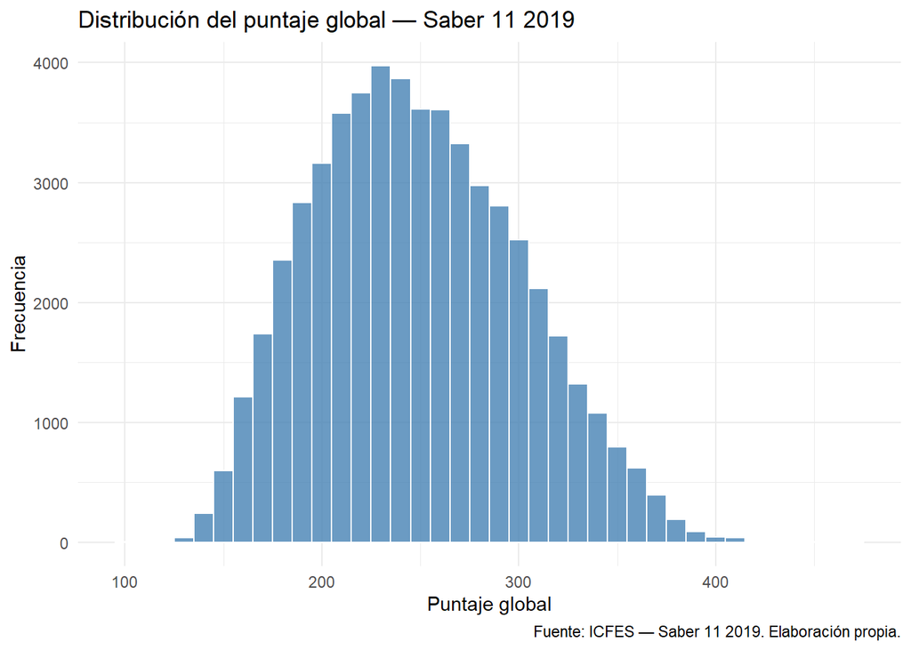

```r
ggplot(sb11, aes(x = punt_global)) +
  geom_histogram(binwidth = 10, fill = "steelblue", color = "white", alpha = 0.8) +
  labs(
    title   = "Distribución del puntaje global — Saber 11 2019",
    x       = "Puntaje global",
    y       = "Frecuencia",
    caption = "Fuente: ICFES — Saber 11 2019. Elaboración propia."
  ) +
  theme_minimal()
```

## 13.2 Histograma por grupo con `facet_wrap()`

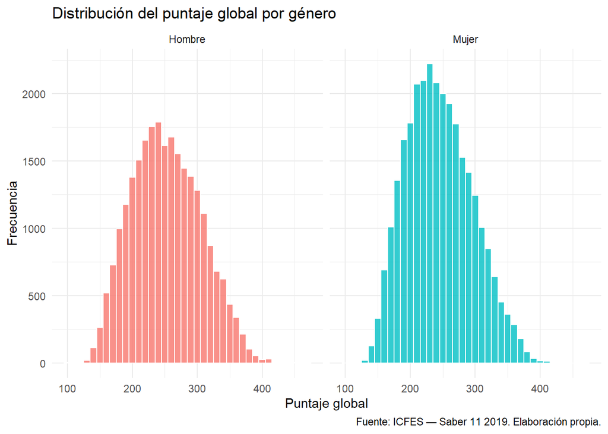

```r
sb11 |>
  mutate(Genero = if_else(mujer == 1, "Mujer", "Hombre")) |>
  ggplot(aes(x = punt_global, fill = Genero)) +
  geom_histogram(binwidth = 10, color = "white", alpha = 0.8) +
  facet_wrap(~ Genero) +
  labs(
    title   = "Distribución del puntaje global por género",
    x       = "Puntaje global",
    y       = "Frecuencia",
    caption = "Fuente: ICFES — Saber 11 2019. Elaboración propia."
  ) +
  theme_minimal() +
  theme(legend.position = "none")
```

## 13.3 Boxplot

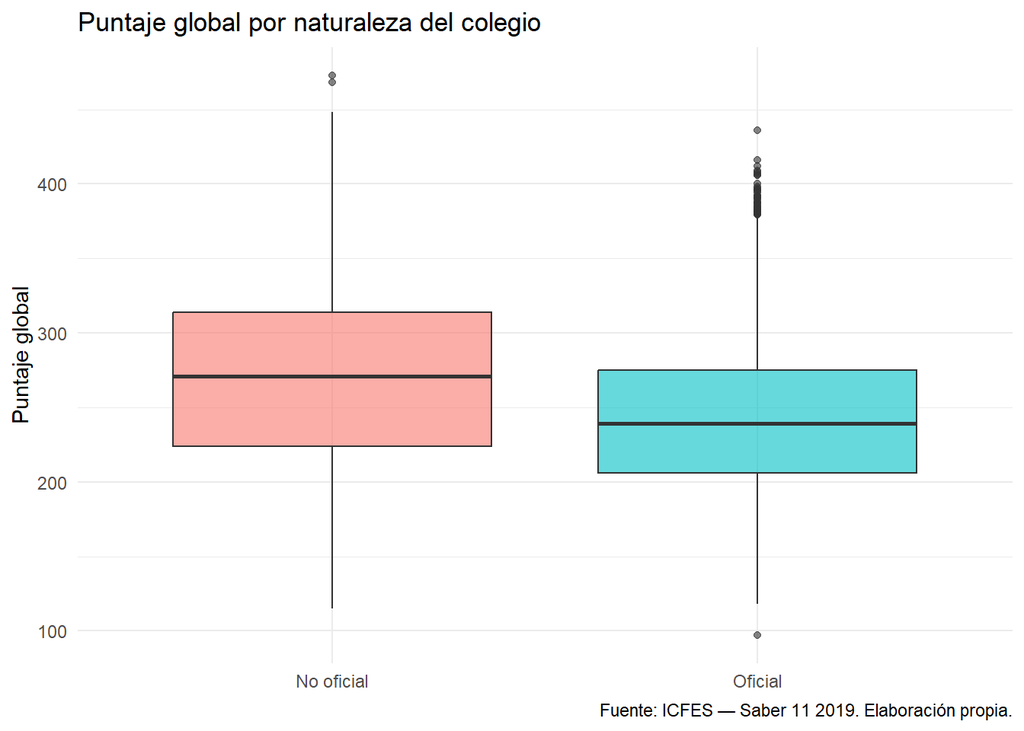

```r
sb11 |>
  mutate(Colegio = if_else(oficial == 1, "Oficial", "No oficial")) |>
  ggplot(aes(x = Colegio, y = punt_global, fill = Colegio)) +
  geom_boxplot(alpha = 0.6) +
  labs(
    title   = "Puntaje global por naturaleza del colegio",
    x       = NULL,
    y       = "Puntaje global",
    caption = "Fuente: ICFES — Saber 11 2019. Elaboración propia."
  ) +
  theme_minimal() +
  theme(legend.position = "none")
```

## 13.4 Gráfico de barras

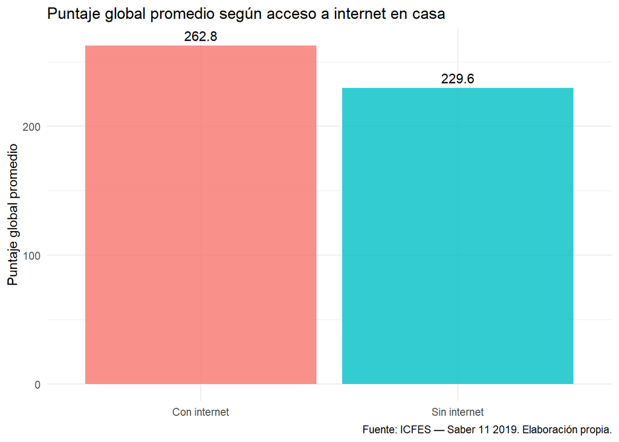

```r
sb11 |>
  filter(!is.na(tiene_internet)) |>
  mutate(Internet = if_else(tiene_internet == 1, "Con internet", "Sin internet")) |>
  group_by(Internet) |>
  summarise(media_global = mean(punt_global, na.rm = TRUE)) |>
  ggplot(aes(x = Internet, y = media_global, fill = Internet)) +
  geom_col(alpha = 0.8) +
  geom_text(aes(label = round(media_global, 1)), vjust = -0.5) +
  labs(
    title   = "Puntaje global promedio según acceso a internet en casa",
    x       = NULL,
    y       = "Puntaje global promedio",
    caption = "Fuente: ICFES — Saber 11 2019. Elaboración propia."
  ) +
  theme_minimal() +
  theme(legend.position = "none")
```

## 13.5 Gráfico de dispersión

El gráfico de dispersión anticipa la regresión OLS que verán en la clase magistral de la semana 2:

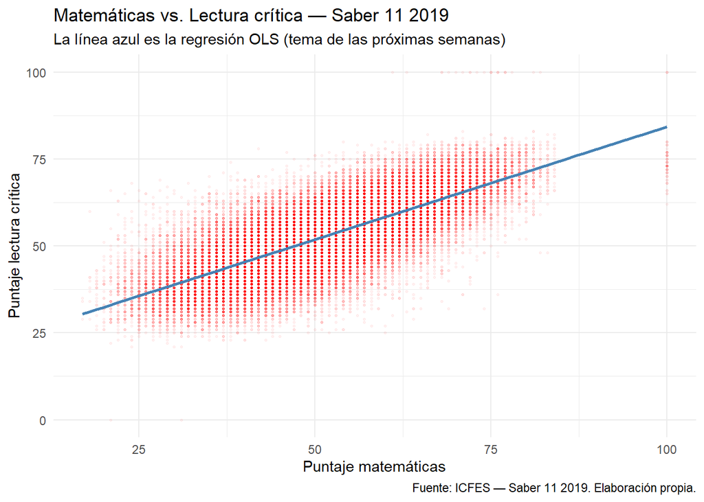

```r
ggplot(sb11, aes(x = punt_matematicas, y = punt_lectura_critica)) +
  geom_point(alpha = 0.05, size = 0.6, color = "red") +
  geom_smooth(method = "lm", color = "steelblue", se = TRUE) +
  labs(
    title    = "Matemáticas vs. Lectura crítica — Saber 11 2019",
    subtitle = "La línea azul es la regresión OLS (tema de las próximas semanas)",
    x        = "Puntaje matemáticas",
    y        = "Puntaje lectura crítica",
    caption  = "Fuente: ICFES — Saber 11 2019. Elaboración propia."
  ) +
  theme_minimal()
```

# 14 Anticipo: el modelo OLS en R

En las clases magistrales aprenderás la teoría del OLS. Aquí un adelanto de cómo se estima en R:

```r
# Estimar una regresión lineal
modelo <- lm(punt_global ~ punt_matematicas + punt_lectura_critica + mujer + oficial,
             data = sb11)

# Ver resultados
summary(modelo)
```

```
#>
#> Call:
#> lm(formula = punt_global ~ punt_matematicas + punt_lectura_critica +
#>     mujer + oficial, data = sb11)
#>
#> Residuals:
#>     Min      1Q  Median      3Q     Max
#> -84.858  -8.842   0.337   9.141  68.555
#>
#> Coefficients:
#>                       Estimate Std. Error t value Pr(>|t|)
#> (Intercept)           4.177695   0.346960  12.041   <2e-16 ***
#> punt_matematicas      2.254944   0.007243 311.341   <2e-16 ***
#> punt_lectura_critica  2.500912   0.008175 305.904   <2e-16 ***
#> mujer                 1.055909   0.117868   8.958   <2e-16 ***
#> oficial              -3.922363   0.134800 -29.098   <2e-16 ***
#> ---
#> Signif. codes:  0 '***' 0.001 '**' 0.01 '*' 0.05 '.' 0.1 ' ' 1
#>
#> Residual standard error: 13.5 on 54614 degrees of freedom
#> Multiple R-squared:  0.9327, Adjusted R-squared:  0.9327
#> F-statistic: 1.892e+05 on 4 and 54614 DF,  p-value: < 2.2e-16
```

```r
# Extraer coeficientes
coef(modelo)
```

```
#>          (Intercept)     punt_matematicas punt_lectura_critica
#>             4.177695             2.254944             2.500912
#>                mujer              oficial
#>             1.055909            -3.922363
```

```r
# Intervalos de confianza al 95%
confint(modelo, level = 0.95)
```

```
#>                          2.5 %    97.5 %
#> (Intercept)           3.497650  4.857740
#> punt_matematicas      2.240749  2.269140
#> punt_lectura_critica  2.484888  2.516936
#> mujer                 0.824887  1.286931
#> oficial              -4.186572 -3.658153
```

> En las próximas clases aprenderán a interpretar cada número de esa tabla y a construir modelos de regresión múltiple con datos reales.

# 15 Consejos para el curso

1. **Escribe código todos los días.** Como cualquier idioma, R se aprende practicando.
2. **Comenta tu código.** Usa `#` para explicar qué hace cada bloque.
3. **Usa proyectos de RStudio.** Mantén tu trabajo organizado por carpetas.
4. **Busca en la documentación.** `?nombre_funcion` en la consola abre la ayuda.
5. **No copies y pegues sin entender.** Reproducibilidad ≠ copy-paste ciego.

# 16 Recursos adicionales

- **Swirl:** aprende R interactivamente desde la consola → `install.packages("swirl"); swirl::swirl()`
- **R for Data Science** (Hadley Wickham): https://r4ds.had.co.nz/ — gratuito en línea
- **Hands-On Programming with R**: https://rstudio-education.github.io/hopr/
- **Documentación de tidyverse**: https://www.tidyverse.org/
- **StackOverflow en español**: https://es.stackoverflow.com/

# 17 Ejercicios prácticos

## 17.1 Ejercicio 1: Objetos y vectores

```r
# 1a. Crea un vector `pib` con los crecimientos del PIB colombiano (%):
#     2.6, 3.3, 1.4, -6.8, 10.6, 7.3, 0.6
#     Calcula la media, la mediana y la desviación estándar.

# 1b. Crea un vector lógico que indique cuáles años tuvieron crecimiento negativo.
#     ¿Cuántos años tuvieron crecimiento negativo?

# 1c. Calcula el crecimiento promedio excluyendo el año con caída más profunda.
```

## 17.2 Ejercicio 2: Data Frames

```r
# 2a. Crea un data frame `empresas` con:
#     - nombre: "Ecopetrol", "Bancolombia", "Grupo Éxito", "Cementos Argos", "ISA"
#     - sector: "Energía", "Financiero", "Retail", "Industria", "Energía"
#     - empleados: 8000, 26000, 35000, 5500, 6000
#     - utilidad_millones: 12500, 8300, -200, 650, 1100

# 2b. Filtra las empresas con utilidad positiva.
# 2c. ¿Cuál es el promedio de empleados?
# 2d. Agrega una columna con la utilidad por empleado.
```

## 17.3 Ejercicio 3: Datos reales (Saber 11)

```r
# Usando la base sb11 que cargaron hoy:

# 3a. Calculen la media y la desviación estándar del puntaje de inglés
#     (punt_ingles) separado por género. ¿Qué grupo tiene mayor puntaje promedio?

# 3b. Creen una variable `estrato_num` que tome valores 1 a 6 según
#     fami_estratovivienda (ignoren "Sin Estrato" y los vacíos).
#     Calculen el puntaje global promedio por estrato. ¿Qué patrón observan?

# 3c. Hagan un boxplot del puntaje de matemáticas separado por si el
#     estudiante tiene computador en casa (fami_tienecomputador).

# 3d. Hagan un gráfico de dispersión entre EDAD_ESTUDIANTES y punt_global.
#     ¿Hay alguna tendencia? ¿En qué dirección?
```

*Clase preparada para Econometría 1 — ECON 3311 / ECON 3321 | Universidad de los Andes | 2026-19*